# R Notebook

```r
library("tidyverse")
library("poppr")
(load("data/sclerotinia_16_loci.rda"))
```

```
[1] "dat"            "dat11"          "datdf"          "keeploci"       "corrected_loci"
```

# Purpose

The white mold nursery populations are unique because they are not fungicide treated and have the same cultivars planted in them year after year.

The question becomes, are white mold nurseries differentiated from each other or are they more or less homogeneous? We could use AMOVA to test for these with location and binary source (wmn or non-wmn) as the hierarchy.

# Data Setup

First, we want to clone-correct our data down to the field level so that we don’t accidentally include non-independent samples.

```r
dat11
```

```
This is a genclone object
-------------------------
Genotype information:

   165 original multilocus genotypes
   366 haploid individuals
    11 codominant loci

Population information:

     5 strata - MCG, Region, Source, Year, Host
    14 populations defined - NE, NY, MN, ..., France, Mexico, ND
```

```r
dat11cc <- clonecorrect(dat11, ~Region/Source/Host/Year)
dat11cc
```

```
This is a genclone object
-------------------------
Genotype information:

   165 original multilocus genotypes
   318 haploid individuals
    11 codominant loci

Population information:

     5 strata - MCG, Region, Source, Year, Host
    14 populations defined - NE, NY, MN, ..., France, Mexico, ND
```

```r
make_amova_table <- function(am, amt, samples = "Region"){
  tot <- nrow(am$results)
  res <- data.frame(list(am$results[-tot, c("Df", "Sum Sq")],
                         Percent = am$componentsofcovariance[-tot, 2],
                         Pval    = rev(amt$pvalue),
                         # Sigma   = rev(amt$)
                         Phi     = rev(am$statphi$Phi[-tot])))
  res <- as.matrix(res)
  colnames(res) <- c("d.f.", "Sum of Squares", "Percent variation", "P",
                     "Phi statistic")
  names(dimnames(res)) <- c("levels", "statistic")
  rownames(res) <- gsub("samples", samples, rownames(res))
  return(res)
}
make_amova_printable <- function(amtab, amtabcc){
  am_array <- array(dim      = c(dim(amtab), 2),
                    dimnames = c(dimnames(amtab),
                                 list(c("full", "clone-corrected"))))
  am_array[, , 1] <- amtab
  am_array[, , 2] <- amtabcc
  tabfun <- function(x){
    x <- paste0(paste0(signif(x, 3), collapse = " ("), ")")
    return(x)
  }
  res <- apply(am_array, c(1, 2), tabfun)
  return(res)
}
```

Now that we’ve done that, we should make a new variable in the strata that separates the white mold nurseries from the others. We’ll call this stratum “Source Type”.

```r
addStrata(dat11cc) <- strata(dat11cc) %>%
  mutate(SourceType = forcats::fct_inorder(ifelse(Source == "wmn", "wmn", "other"))) %>%
  select(SourceType)
setPop(dat11cc) <- ~SourceType
dat11cc
```

```
This is a genclone object
-------------------------
Genotype information:

   165 original multilocus genotypes
   318 haploid individuals
    11 codominant loci

Population information:

     6 strata - MCG, Region, Source, Year, Host, SourceType
     2 populations defined - other, wmn
```

I can perform AMOVA on the newly defined variable using Bruvo’s distance.

```r
other(dat11cc)$REPLEN
```

```
  5-2(F)   5-3(F)   6-2(F)   7-2(F)   8-3(H)   9-2(F)  12-2(H)  17-3(H)  20-3(F)  36-4(F)
 2.00000  4.00000  5.99999  2.00000  2.00000  2.00000  2.00000  3.00000  2.00000  4.00000
 50-4(F)  55-4(F)  92-4(F) 106-4(H) 110-4(H) 114-4(H)
 4.00000  4.00000  2.00000  4.00000  3.99999  4.00000
```

```r
bd <- bruvo.dist(dat11cc, replen = other(dat11cc)$REPLEN)
(ssc_amova <- poppr.amova(dat11cc, ~SourceType, dist = bd, quiet = TRUE))
```

```
$call
ade4::amova(samples = xtab, distances = xdist, structures = xstruct)

$results
                 Df     Sum Sq   Mean Sq
Between samples   1  0.8969901 0.8969901
Within samples  316 68.7005529 0.2174068
Total           317 69.5975430 0.2195506

$componentsofcovariance
                                  Sigma          %
Variations  Between samples 0.004391536   1.979968
Variations  Within samples  0.217406813  98.020032
Total variations            0.221798349 100.000000

$statphi
                         Phi
Phi-samples-total 0.01979968
```

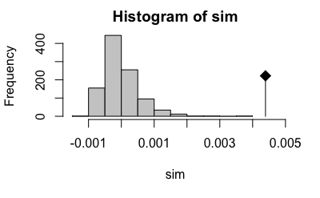

```r
ssc_amova_test <- randtest(ssc_amova, nrepet = 999)
plot(ssc_amova_test)
```

```r
ssc_amova_test
```

```
Monte-Carlo test
Call: as.randtest(sim = res, obs = sigma[1])

Observation: 0.004391536

Based on 999 replicates
Simulated p-value: 0.001
Alternative hypothesis: greater

      Std.Obs   Expectation      Variance
 8.285307e+00 -2.060275e-05  2.835836e-07
```

This result is telling us that there is some subdivision between white mold nurseries and non-white mold nurseries. Of course, from previous analyses, we know that Mexico is differentiated from other populations, so what happens if we account for Region? Here, we are placing region lower in the heirarchy because we specifically want to test the effect of region on the differentiation between white mold nurseries within different regions.

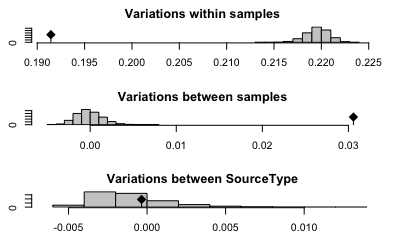

```r
ssc_amova_region <- poppr.amova(dat11cc, ~SourceType/Region, dist = bd, quiet = TRUE)
ssc_amova_region_test <- randtest(ssc_amova_region, nrepet = 9999)
plot(ssc_amova_region_test)
```

```r
(ssc_amova_table <- make_amova_table(ssc_amova_region, ssc_amova_region_test))
```

```
                                  statistic
levels                             d.f. Sum of Squares Percent variation      P Phi statistic
  Between SourceType                  1      0.8969901        -0.1583345 0.2891  -0.001583345
  Between Region Within SourceType   20     12.0338468        13.7964379 0.0001   0.137746279
  Within Region                     296     56.6667061        86.3618966 0.0001   0.136381034
```

Okay! This shows that when we account for Region after accounting for Source Type, we find that the differentiation is coming mainly from the Regions. What happens when we remove Mexico?

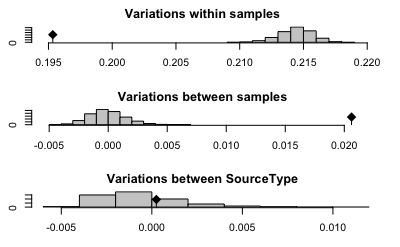

```r
datnomex <- setPop(dat11cc, ~Region) %>% popsub(blacklist = "Mexico")
bdnm     <- bruvo.dist(datnomex, replen = other(datnomex)$REPLEN)
ssc_amova_nm <- poppr.amova(datnomex, ~SourceType/Region, dist = bdnm, quiet = TRUE)
ssc_amova_nm_test <- randtest(ssc_amova_nm, nrepet = 9999)
plot(ssc_amova_nm_test)
```

```r
(ssc_amova_nm_table <- make_amova_table(ssc_amova_nm, ssc_amova_nm_test))
```

```
                                  statistic
levels                             d.f. Sum of Squares Percent variation      P Phi statistic
  Between SourceType                  1      0.7527864          0.115560 0.2783    0.00115560
  Between Region Within SourceType   19      8.9146924          9.534715 0.0001    0.09545746
  Within Region                     282     55.0854125         90.349725 0.0001    0.09650275
```

When we remove the Mexican isolates (which only contained white mold nurseries and shared no genotypes), we see that indeed, the degree of differentiation went down. Of course, if we look at the distribution of isolates between white mold nurseries and regions, we can see things are a bit lopsided:

```r
table(strata(dat11cc, ~SourceType/Region, combine = FALSE))
```

```
          Region
SourceType NE NY MN MI OR WA CO WI ID Australia CA France Mexico ND
     other 13  1  0 18  2 23 33  2  1         2  0      4      0 34
     wmn   24  0  9 40 15 35  1  0  0         4 18     17     15  7
```

The only regions that have at least ten samples in both white mold nurseries and production regions are NE, WA, and MI. We can see what happens when we subsample to these

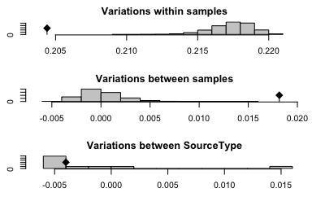

```r
datnewami <- setPop(dat11cc, ~Region) %>% popsub(sublist = c("NE", "WA", "MI"))
bdnewami     <- bruvo.dist(datnewami, replen = other(datnewami)$REPLEN)
ssc_amova_newami <- poppr.amova(datnewami, ~SourceType/Region, dist = bdnewami, quiet = TRUE)
ssc_amova_newami_test <- randtest(ssc_amova_newami, nrepet = 9999)
plot(ssc_amova_newami_test)
```

```r
(ssc_amova_newami_table <- make_amova_table(ssc_amova_newami, ssc_amova_newami_test))
```

```
                                  statistic
levels                             d.f. Sum of Squares Percent variation      P Phi statistic
  Between SourceType                  1      0.3672025         -1.831835 0.4048   -0.01831835
  Between Region Within SourceType    4      2.6285603          8.309128 0.0001    0.08159657
  Within Region                     147     30.0470395         93.522707 0.0001    0.06477293
```

```r
make_amova_printable(ssc_amova_table, ssc_amova_newami_table) %>%
  as_tibble() %>%
  add_column(Hierarchy = c("Between Source", "Between Region within Source", "Within Region"), .before = 1) %>%
  readr::write_csv(path = file.path(PROJHOME, "results", "tables", "AMOVA-region.csv"), col_names = TRUE) %>%
  rename(ps = `Phi statistic`) %>%
  mutate(ps = gsub("0\\.00(\\d{1})(\\d{2})", "\\1.\\2e^-3^", ps)) %>%
  mutate(ps = case_when(Hierarchy == "Between Source" ~ ps, TRUE ~ paste0("**", ps, "**"))) %>%
  rename(`$\\Phi statistic$` = ps) %>%
  rename(`% variation` = `Percent variation`) %>%
  rename(S.S. = `Sum of Squares`) %>%
  select(-P) %>%
  huxtable::as_huxtable(add_colnames = TRUE) %>%
  huxtable::set_col_width(c(1.1, 0.6, 0.8, 0.8, 1.1)) %>%
  huxtable::set_align(huxtable::everywhere, 2:5, "center") %>%
  huxtable::print_md(max_width = 90)
```

```
---------------------------------------------------------------------------------------
Hierarchy                d.f.          S.S.         % variation     $\Phi statistic$
--------------------- ----------- --------------- --------------- ---------------------
Between Source           1 (1)     0.897 (0.367)  -0.158 (-1.83)  -1.58e^-3^ (-0.0183)

Between Region within   20 (4)       12 (2.63)      13.8 (8.31)    **0.138 (0.0816)**
 Source

Within Region          296 (147)     56.7 (30)      86.4 (93.5)    **0.136 (0.0648)**

---------------------------------------------------------------------------------------
```

## Visualizing the partitions

We can visualize the partitions if we create distributions showing the genetic distance.

```r
wmn_inds <- (setPop(dat11cc, ~SourceType) %>% pop()) == "wmn"
# Function to set the upper triangle to NA to avoid over-representation.
set_upper_tri_NA <- function(d){d[upper.tri(d)] <- NA; diag(d) <- NA; d}
# dist data converted to matrix fed into here. Removes NAs from previous function
tidy_dist <- . %>%
  as.data.frame() %>%
  rownames_to_column("from") %>%
  gather(to, distance, -from) %>%
  filter(!is.na(distance))
wmn_distance   <- as.matrix(bd)[wmn_inds, wmn_inds] %>% set_upper_tri_NA() %>% tidy_dist
nwmn_distance  <- as.matrix(bd)[!wmn_inds, !wmn_inds] %>% set_upper_tri_NA() %>% tidy_dist
inter_distance <- as.matrix(bd)[wmn_inds, !wmn_inds] %>% tidy_dist
dists <- bind_rows(`White Mold Nurseries` = wmn_distance,
                   `Between` = inter_distance,
                   `Other Sources` = nwmn_distance,
                   .id = "Comparison") %>%
  mutate(Comparison = forcats::fct_inorder(Comparison)) %>%
  as_tibble()
dists
```

| Comparison | from | to | distance |
| --- | --- | --- | --- |
| White Mold Nurseries | 445 | 444 | 0.00000000 |
| White Mold Nurseries | 446 | 444 | 0.30681818 |
| White Mold Nurseries | 447 | 444 | 0.26136364 |
| White Mold Nurseries | 448 | 444 | 0.37500000 |
| White Mold Nurseries | 449 | 444 | 0.31818182 |
| White Mold Nurseries | 450 | 444 | 0.22727273 |
| White Mold Nurseries | 451 | 444 | 0.09090909 |
| White Mold Nurseries | 452 | 444 | 0.18181818 |
| White Mold Nurseries | 453 | 444 | 0.00000000 |
| White Mold Nurseries | 454 | 444 | 0.09090909 |

[output cut: 990 more lines]

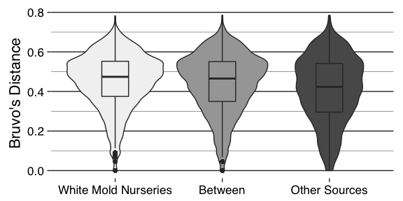

```r
ggplot(dists, aes(y = distance, x = Comparison, fill = Comparison)) +
  geom_violin() +
  geom_boxplot(width = 0.25) +
  scale_fill_manual(values =  c(`Other Sources` = "grey35", `White Mold Nurseries` = "grey95", Between = "grey65")) +
  scale_color_manual(values = c(`Other Sources` = "grey35", `White Mold Nurseries` = "grey95", Between = "grey65")) +
  theme_bw(base_size = 16, base_family = "Helvetica") +
  theme(aspect.ratio = 1/2) +
  theme(legend.position = "none") +
  theme(axis.title.x = element_blank()) +
  theme(axis.text = element_text(color = "black")) +
  theme(panel.grid.major = element_line(colour = "grey20")) +
  theme(panel.grid.minor = element_line(colour = "grey50")) +
  theme(panel.grid.major.x = element_blank()) +
  theme(panel.border = element_blank()) +
  ylab("Bruvo's Distance")
```

```r
summary_dists <- dists %>%
  group_by(Comparison) %>%
  summarize(`Average Distance` = mean(distance),
            `Standard Deviation` = sd(distance))
knitr::kable(summary_dists, digits = 3)
```

| Comparison | Average Distance | Standard Deviation |
| --- | --- | --- |
| White Mold Nurseries | 0.453 | 0.139 |
| Between | 0.440 | 0.148 |
| Other Sources | 0.410 | 0.165 |

On first look, it appears that there’s not much difference. Looking at the table, we can see that the average distance within White Mold Nurseries is 0.453, whereas the average distance within Other Sources is 0.41. This is well within the standard deviation for both distributions, but we also recognize that a single step of Bruvo’s distance for 11 loci in a haploid organism is 0.045.

## WMN DAPC

DAPC is a nice way of visualizing these. First, I’m simply going to compare between white mold nurseries and others:

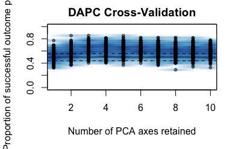

```r
filter <- strata(dat11cc) %>%
  group_by(Region) %>%
  mutate(filter = length(unique(SourceType)) > 1) %>%
  pull(filter)
wmn_compare <- dat11cc[filter]
set.seed(2017-07-12)
wmndapc <- xvalDapc(tab(wmn_compare), pop(wmn_compare), n.rep = 200, n.pca = 1:10)
```

```r
wmndapc$DAPC
```

```
    #################################################
    # Discriminant Analysis of Principal Components #
    #################################################
class: dapc
$call: dapc.data.frame(x = as.data.frame(x), grp = ..1, n.pca = ..2,
    n.da = ..3)

$n.pca: 3 first PCs of PCA used
$n.da: 1 discriminant functions saved
$var (proportion of conserved variance): 0.423

$eig (eigenvalues): 15.52  vector    length content
1 $eig      1      eigenvalues
2 $grp      272    prior group assignment
3 $prior    2      prior group probabilities
4 $assign   272    posterior group assignment
5 $pca.cent 69     centring vector of PCA
6 $pca.norm 69     scaling vector of PCA
7 $pca.eig  58     eigenvalues of PCA

  data.frame    nrow ncol content
1 $tab          272  3    retained PCs of PCA
2 $means        2    3    group means
3 $loadings     3    1    loadings of variables
4 $ind.coord    272  1    coordinates of individuals (principal components)
5 $grp.coord    2    1    coordinates of groups
6 $posterior    272  2    posterior membership probabilities
7 $pca.loadings 69   3    PCA loadings of original variables
8 $var.contr    69   1    contribution of original variables
```

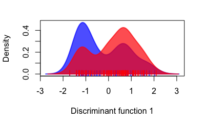

```r
scatter(wmndapc$DAPC)
```

```r
(wmntab <- table(wmndapc$DAPC$assign, wmndapc$DAPC$grp))
```

```
        other wmn
  other    73  40
  wmn      56 103
```

```r
chisq.test(wmntab, simulate.p.value = TRUE)
```

```
    Pearson's Chi-squared test with simulated p-value (based on 2000 replicates)

data:  wmntab
X-squared = 22.87, df = NA, p-value = 0.0004998
```

Okay, this shows that there’s quite a bit of overlap between these two. What happens if I look at the DAPC when it includes the pouplation groupings. Mainly, I want to know if the white mold nurseries can be compared while considering the pouplations

```
1 group has only 1 member so it cannot be represented in both training and validation sets.
```

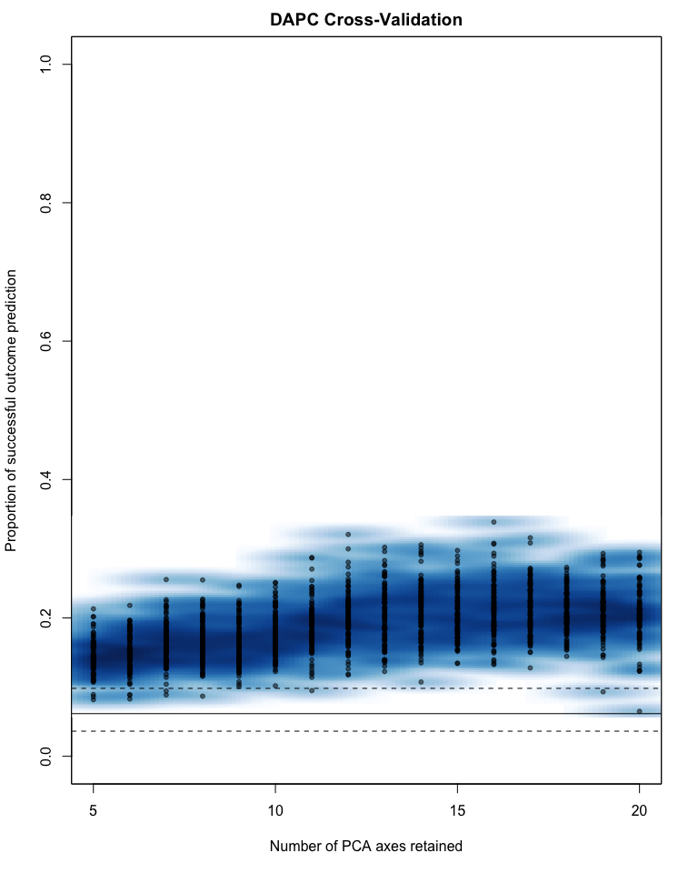

```r
set.seed(2017-07-12)
wmndapc <- xvalDapc(tab(wmn_compare), strata(wmn_compare, ~SourceType/Region)[[2]],
                    n.pca = 5:20, n.rep = 100)$DAPC
```

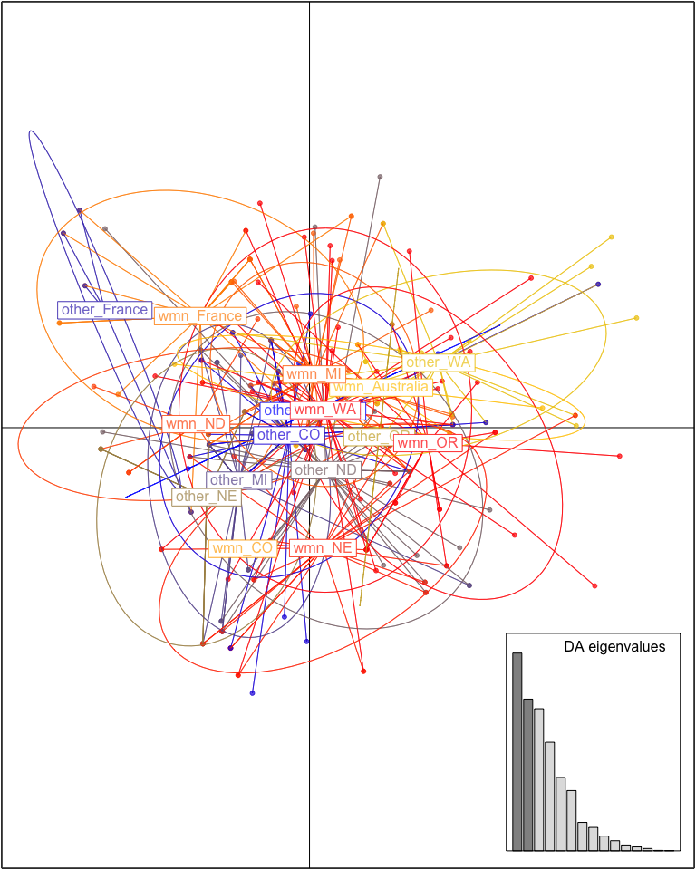

```r
scatter(wmndapc)
```

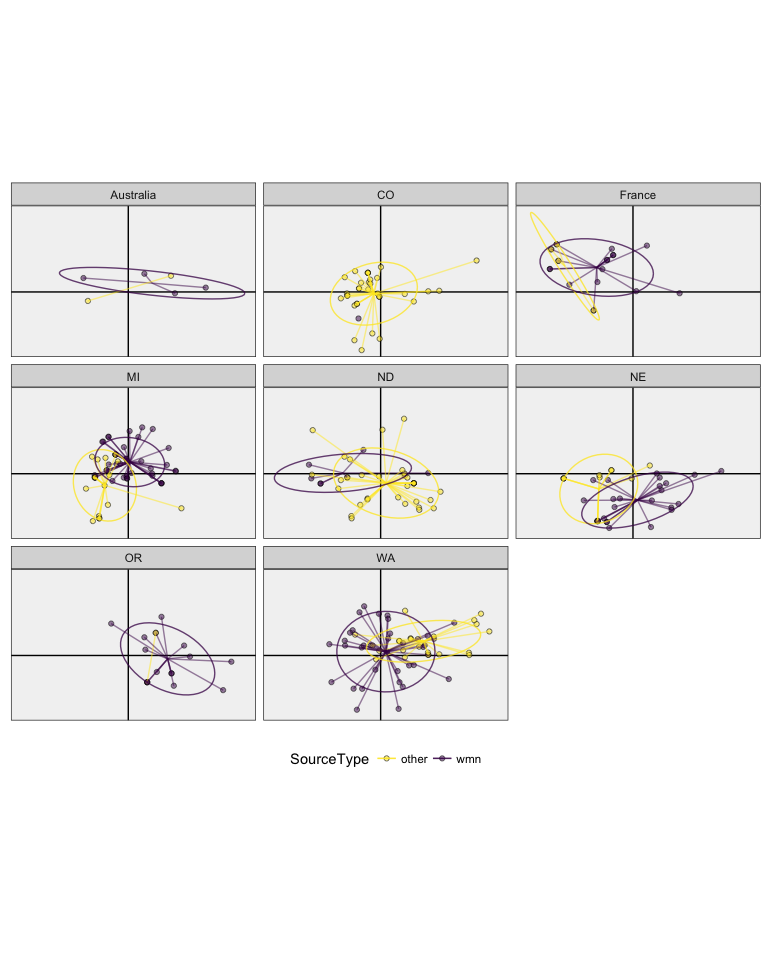

```r
LDS <- bind_cols(Population = wmndapc$grp, as.data.frame(wmndapc$ind.coord)) %>%
  as_tibble()
LDS_pop <- LDS %>%
  group_by(Population) %>%
  summarize_all(mean) %>%
  rename_all(function(x) gsub("LD", "mean", x))
LDS <- full_join(LDS, LDS_pop) %>%
  separate(Population, c("SourceType", "Pop"), remove = FALSE)
LDS_PLOT <- ggplot(LDS, aes(x = LD1, y = LD2, color = SourceType)) +
  geom_point(aes(fill = SourceType), alpha = 0.5, pch = 21, color = "black") +
  geom_segment(aes(x = mean1, y = mean2, xend = LD1, yend = LD2), alpha = 0.5) +
  stat_ellipse(type = "norm", level = 0.66, alpha = 0.75) +
  # ggrepel::geom_label_repel(aes(x = mean1, y = mean2, label = Population),
  #                           data = LDS_pop, show.legend = FALSE, color = "black") +
  theme_bw() +
  theme(aspect.ratio = 1/1.618) +
  theme(legend.position = "bottom") +
  theme(axis.text = element_blank()) +
  theme(axis.title = element_blank()) +
  theme(axis.ticks = element_blank()) +
  viridis::scale_color_viridis(discrete = TRUE, direction = -1) +
  viridis::scale_fill_viridis(discrete = TRUE, direction = -1) +
  scale_y_continuous(breaks = 0) +
  scale_x_continuous(breaks = 0) +
  theme(panel.background = element_rect(fill = "grey95")) +
  theme(panel.grid.major = element_line(color = "black"))
LDS_PLOT + facet_wrap(~Pop, ncol = 3)
```

# Host differentiation

There are three main hosts shared within the white mold nurseries:

| Cultivar | Susceptibility |
| --- | --- |
| Beryl | Susceptible |
| Bunsi | ? |
| G122 | Some Resistance |

These hosts are grown in the nurseries at different times and it is of interest if cultivar can have an effect on population structure. Given the results of Aldrich-Wolfe 2015, I would suspect that cultivar has no effect, but it’s important to verify this. We are going to use AMOVA and DAPC for this.

```r
bebug <- dat11cc %>%
  setPop(~Source) %>%
  popsub("wmn") %>%
  setPop(~Host) %>%
  popsub(c("Beryl", "Bunsi", "G122"))
bebugd <- bruvo.dist(bebug, replen = other(bebug)$REPLEN)
(ssc_host_amova <- poppr.amova(bebug, ~Host, dist = bebugd, quiet = TRUE))
```

```
$call
ade4::amova(samples = xtab, distances = xdist, structures = xstruct)

$results
                 Df     Sum Sq   Mean Sq
Between samples   2  0.2965933 0.1482967
Within samples  154 35.1688676 0.2283693
Total           156 35.4654609 0.2273427

$componentsofcovariance
                                  Sigma           %
Variations  Between samples -0.00153422  -0.6763594
Variations  Within samples   0.22836927 100.6763594
Total variations             0.22683505 100.0000000

$statphi
                           Phi
Phi-samples-total -0.006763594
```

```r
(ssc_host_amova <- poppr.amova(bebug, ~Host/Region, dist = bebugd, quiet = TRUE))
```

```
$call
ade4::amova(samples = xtab, distances = xdist, structures = xstruct)

$results
                             Df     Sum Sq   Mean Sq
Between Host                  2  0.2965933 0.1482967
Between samples Within Host  27 11.2172536 0.4154538
Within samples              127 23.9516140 0.1885954
Total                       156 35.4654609 0.2273427

$componentsofcovariance
                                              Sigma          %
Variations  Between Host                -0.00648971  -2.861074
Variations  Between samples Within Host  0.04472212  19.716331
Variations  Within samples               0.18859539  83.144743
Total variations                         0.22682779 100.000000

$statphi
                          Phi
Phi-samples-total  0.16855257
Phi-samples-Host   0.19167923
Phi-Host-total    -0.02861074
```

The AMOVA makes it clear that there’s no differentiation between hosts. Let’s see what DAPC shows us.

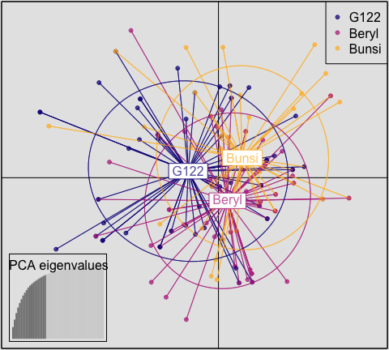

```r
setPop(bebug) <- ~Host
bebug_dapc <- dapc(bebug, n.pca = 20, n.da = 2)
scatter(bebug_dapc, #clabel = 0,
        legend = TRUE,
        scree.pca = TRUE,
        scree.da = FALSE,
        col = viridis::plasma(3, end = 0.85),
        bg.inset = "grey90",
        bg = "grey90")
```

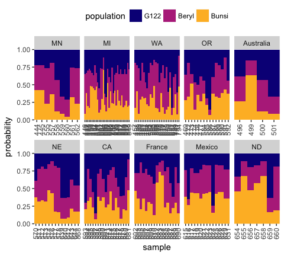

```r
ggcompoplot::ggcompoplot(bebug_dapc, setPop(bebug, ~Region), cols = 5, pal = viridis::plasma(3, end = 0.85)) +
  theme(legend.position = "top")
```

```r
apply(bebug_dapc$posterior, 2, mean)
```

```
     G122     Beryl     Bunsi
0.3397300 0.3594735 0.3007965
```

```r
setPop(bebug) <- ~Host/Region
bebug_dapc <- dapc(bebug, n.pca = 20, n.da = 20)
bebug_dapc
```

```
    #################################################
    # Discriminant Analysis of Principal Components #
    #################################################
class: dapc
$call: dapc.genind(x = bebug, n.pca = 20, n.da = 20)

$n.pca: 20 first PCs of PCA used
$n.da: 20 discriminant functions saved
$var (proportion of conserved variance): 0.887

$eig (eigenvalues): 31.72 7.385 5.33 4.425 4.026 ...

  vector    length content
1 $eig      20     eigenvalues
2 $grp      157    prior group assignment
3 $prior    30     prior group probabilities
4 $assign   157    posterior group assignment
5 $pca.cent 66     centring vector of PCA
6 $pca.norm 66     scaling vector of PCA
7 $pca.eig  54     eigenvalues of PCA

  data.frame    nrow ncol content
1 $tab          157  20   retained PCs of PCA
2 $means        30   20   group means
3 $loadings     20   20   loadings of variables
4 $ind.coord    157  20   coordinates of individuals (principal components)
5 $grp.coord    30   20   coordinates of groups
6 $posterior    157  30   posterior membership probabilities
7 $pca.loadings 66   20   PCA loadings of original variables
8 $var.contr    66   20   contribution of original variables
```

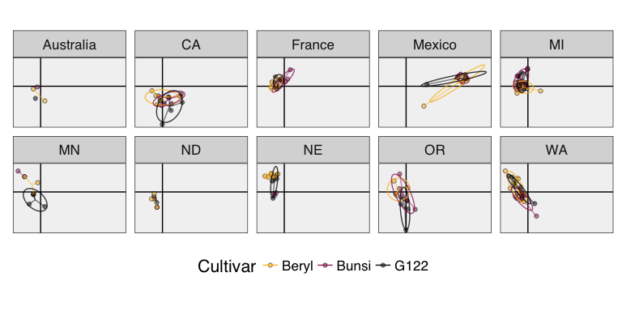

```r
LDS <- bind_cols(Population = bebug_dapc$grp, as.data.frame(bebug_dapc$ind.coord)) %>%
  as_tibble()
LDS_pop <- LDS %>%
  group_by(Population) %>%
  summarize_all(mean) %>%
  rename_all(function(x) gsub("LD", "mean", x))
LDS <- full_join(LDS, LDS_pop, by = "Population") %>% separate(Population, c("Cultivar", "Population"))
LDS_PLOT <- ggplot(LDS, aes(x = LD1, y = LD2, color = Cultivar)) +
  geom_point(aes(fill = Cultivar), alpha = 0.5, pch = 21, color = "black") +
  geom_segment(aes(x = mean1, y = mean2, xend = LD1, yend = LD2), alpha = 0.5) +
  stat_ellipse(type = "norm", level = 0.66, alpha = 0.75) +
  theme_bw(base_size = 16, base_family = "Helvetica") +
  theme(aspect.ratio = 1/1.618) +
  theme(legend.position = "bottom") +
  theme(axis.text = element_blank()) +
  theme(axis.title = element_blank()) +
  theme(axis.ticks = element_blank()) +
  viridis::scale_color_viridis(option = "B", discrete = TRUE, direction = -1, end = 0.85) +
  viridis::scale_fill_viridis(option = "B", discrete = TRUE, direction = -1, end = 0.85) +
  scale_y_continuous(breaks = 0) +
  scale_x_continuous(breaks = 0) +
  theme(panel.background = element_rect(fill = "grey95")) +
  theme(panel.grid.major = element_line(color = "black")) +
  facet_wrap(~Population, nrow = 2)
LDS_PLOT
```

```
 setting  value
 version  R version 3.4.1 (2017-06-30)
 system   x86_64, darwin15.6.0
 ui       RStudio (1.1.348)
 language (EN)
 collate  en_US.UTF-8
 tz       America/Chicago
 date     2017-08-29
```

```
Packages ------------------------------------------------------------------------------------------
```

[output not shown]

[output cut: 54 more lines]

[output not shown]